# homework-4

Riley Maher

12/2/2020

# Homework 4

## Importing Packages

```r
library(ggplot2)
library(tidyverse)
library(gender)
library(leaflet)
library(udpipe)
library(textrank)

model <- udpipe_download_model(language = "english")
```

```
##  - This model has been trained on version 2.5 of data from https://universaldependencies.org
```

```
##  - The model is distributed under the CC-BY-SA-NC license: https://creativecommons.org/licenses/by-nc-sa/4.0
```

```
##  - Visit https://github.com/jwijffels/udpipe.models.ud.2.5 for model license details.
```

[output not shown]

## Reading Data

```r
# Reading in and cleaning the data
airbnb <- read.csv('Modified_AB_NYC_2019.csv')
airbnb$id <- NULL
airbnb$X <- NULL
airbnb$reviews_per_month <- ifelse(is.na(airbnb$reviews_per_month) == TRUE, 0,
                                   airbnb$reviews_per_month)

head(airbnb)
```

```
##                                               name host_id   host_name
## 1               Clean & quiet apt home by the park    2787        John
## 2                            Skylit Midtown Castle    2845    Jennifer
## 3              THE VILLAGE OF HARLEM....NEW YORK !    4632   Elisabeth
## 4                  Cozy Entire Floor of Brownstone    4869 LisaRoxanne
## 5 Entire Apt: Spacious Studio/Loft by central park    7192       Laura
## 6        Large Cozy 1 BR Apartment In Midtown East    7322       Chris
##   neighbourhood_group neighbourhood latitude longitude       room_type price
## 1            Brooklyn    Kensington 40.64749 -73.97237    Private room   149
## 2           Manhattan       Midtown 40.75362 -73.98377 Entire home/apt   225
## 3           Manhattan        Harlem 40.80902 -73.94190    Private room   150
## 4            Brooklyn  Clinton Hill 40.68514 -73.95976 Entire home/apt    89
## 5           Manhattan   East Harlem 40.79851 -73.94399 Entire home/apt    80
## 6           Manhattan   Murray Hill 40.74767 -73.97500 Entire home/apt   200
##   minimum_nights number_of_reviews last_review reviews_per_month
## 1              1                 9  2018-10-19              0.21
## 2              1                45  2019-05-21              0.38
## 3              3                 0                          0.00
## 4              1               270  2019-07-05              4.64
## 5             10                 9  2018-11-19              0.10
## 6              3                74  2019-06-22              0.59
##   calculated_host_listings_count availability_365 gender
## 1                              6              365   male
## 2                              2              355 female
## 3                              1              365 female
## 4                              1              194  other
## 5                              1                0 female
## 6                              1              129   male
```

## Data Structure and Summary

```r
# Structure of the data
str(airbnb)
```

```
## 'data.frame':    48895 obs. of  16 variables:
##  $ name                          : chr  "Clean & quiet apt home by the park" "Skylit Midtown Castle" "THE VILLAGE OF HARLEM....NEW YORK !" "Cozy Entire Floor of Brownstone" ...
##  $ host_id                       : int  2787 2845 4632 4869 7192 7322 7356 8967 7490 7549 ...
##  $ host_name                     : chr  "John" "Jennifer" "Elisabeth" "LisaRoxanne" ...
##  $ neighbourhood_group           : chr  "Brooklyn" "Manhattan" "Manhattan" "Brooklyn" ...
##  $ neighbourhood                 : chr  "Kensington" "Midtown" "Harlem" "Clinton Hill" ...
##  $ latitude                      : num  40.6 40.8 40.8 40.7 40.8 ...
##  $ longitude                     : num  -74 -74 -73.9 -74 -73.9 ...
##  $ room_type                     : chr  "Private room" "Entire home/apt" "Private room" "Entire home/apt" ...
##  $ price                         : int  149 225 150 89 80 200 60 79 79 150 ...
##  $ minimum_nights                : int  1 1 3 1 10 3 45 2 2 1 ...
##  $ number_of_reviews             : int  9 45 0 270 9 74 49 430 118 160 ...
##  $ last_review                   : chr  "2018-10-19" "2019-05-21" "" "2019-07-05" ...
##  $ reviews_per_month             : num  0.21 0.38 0 4.64 0.1 0.59 0.4 3.47 0.99 1.33 ...
##  $ calculated_host_listings_count: int  6 2 1 1 1 1 1 1 1 4 ...
##  $ availability_365              : int  365 355 365 194 0 129 0 220 0 188 ...
##  $ gender                        : chr  "male" "female" "female" "other" ...
```

```r
# Summary of the data
summary(airbnb)
```

```
##      name              host_id           host_name         neighbourhood_group
##  Length:48895       Min.   :     2438   Length:48895       Length:48895
##  Class :character   1st Qu.:  7822033   Class :character   Class :character
##  Mode  :character   Median : 30793816   Mode  :character   Mode  :character
##                     Mean   : 67620011
##                     3rd Qu.:107434423
##                     Max.   :274321313
##  neighbourhood         latitude       longitude       room_type
##  Length:48895       Min.   :40.50   Min.   :-74.24   Length:48895
##  Class :character   1st Qu.:40.69   1st Qu.:-73.98   Class :character
##  Mode  :character   Median :40.72   Median :-73.96   Mode  :character
##                     Mean   :40.73   Mean   :-73.95
##                     3rd Qu.:40.76   3rd Qu.:-73.94
##                     Max.   :40.91   Max.   :-73.71
##      price         minimum_nights    number_of_reviews last_review
##  Min.   :    0.0   Min.   :   1.00   Min.   :  0.00    Length:48895
##  1st Qu.:   69.0   1st Qu.:   1.00   1st Qu.:  1.00    Class :character
##  Median :  106.0   Median :   3.00   Median :  5.00    Mode  :character
##  Mean   :  152.7   Mean   :   7.03   Mean   : 23.27
##  3rd Qu.:  175.0   3rd Qu.:   5.00   3rd Qu.: 24.00
##  Max.   :10000.0   Max.   :1250.00   Max.   :629.00
##  reviews_per_month calculated_host_listings_count availability_365
##  Min.   : 0.000    Min.   :  1.000                Min.   :  0.0
##  1st Qu.: 0.040    1st Qu.:  1.000                1st Qu.:  0.0
##  Median : 0.370    Median :  1.000                Median : 45.0
##  Mean   : 1.091    Mean   :  7.144                Mean   :112.8
##  3rd Qu.: 1.580    3rd Qu.:  2.000                3rd Qu.:227.0
##  Max.   :58.500    Max.   :327.000                Max.   :365.0
##     gender
##  Length:48895
##  Class :character
##  Mode  :character
##
##
##
```

## Initial Data Analysis

### Room Type Breakdown

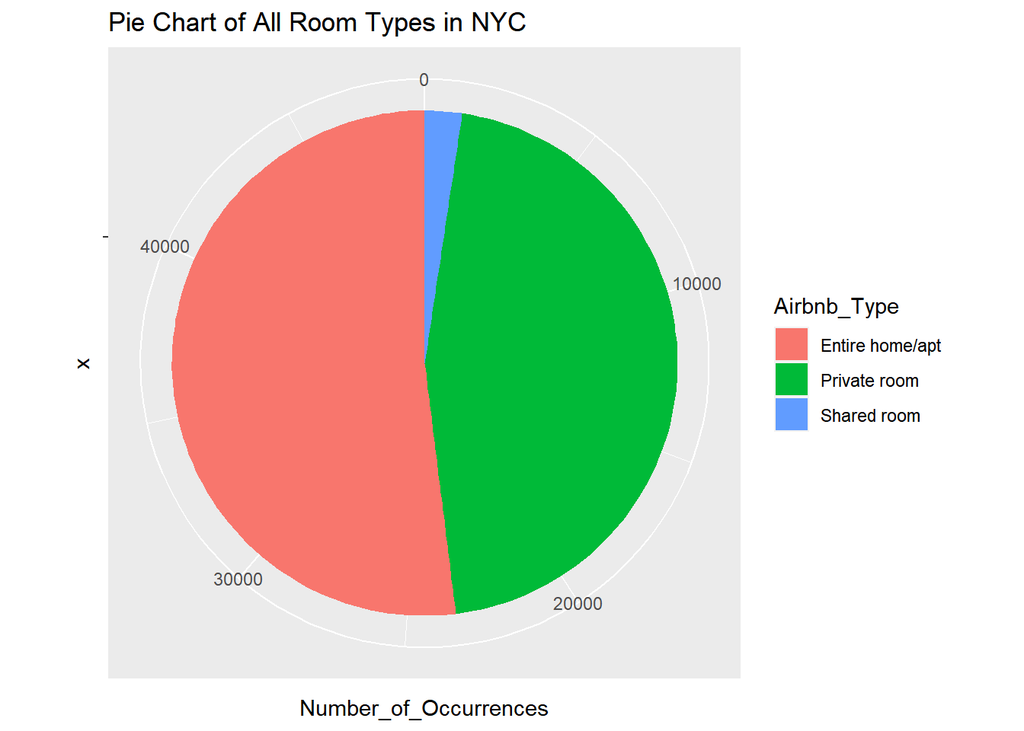

```r
# Pie Chart of types of airbnbs
wiz <- data.frame(table(airbnb$room_type))
names(wiz)[names(wiz) == "Var1"] <- "Airbnb_Type"
names(wiz)[names(wiz) == "Freq"] <- "Number_of_Occurrences"

wiz %>%
  ggplot(aes(x="", y=Number_of_Occurrences, fill=Airbnb_Type)) +
  labs(title="Pie Chart of All Room Types in NYC") +
  geom_bar(stat="identity", width=1) +
  coord_polar("y", start=0)
```

The most common type of airbnb is the Entire home/apt airbnb type with 25409 occurrences. The second most is the Private room airbnb type with 22326 occurrences. The difference between the two is very small, with very few options being the Shared room type.

```r
# Average price by room type
price_per_airbnb_type <- round(tapply(airbnb$price,
                                      airbnb$room_type, mean, na.rm=TRUE), 2)
price_per_airbnb_type
```

```
## Entire home/apt    Private room     Shared room
##          211.79           89.78           70.13
```

When we look at the average price for each airbnb type, we get that the Entire home/apt airbnb type is the most expensive. This makes sense because you get more space in a home rather than in a room. The least expensive is Shared room, which also makes sense, as you would probably be sharing a room with someone else to save money.

```r
# Average number of reviews by room type
reviews_per_airbnb_type <- tapply(airbnb$reviews_per_month,
                                   airbnb$room_type, mean, na.rm=TRUE)
reviews_per_airbnb_type
```

```
## Entire home/apt    Private room     Shared room
##        1.045509        1.143493        1.073345
```

The number of reviews per type doesn’t differ greatly between the airbnb types. The airbnb type with the most reviews on average is Private room.

### Borough Type Breakdown

[figure not shown]

```r
# Number of airbnbs by borough type
borough_group <- data.frame(sort(table(airbnb$neighbourhood_group)))
names(borough_group)[names(borough_group) == "Var1"] <- "Borough"

borough_group %>%
  ggplot(aes(x = Borough, y = Freq)) +
  labs(title="Number Airbnbs per Borough", x="Borough Name", y="Count") +
  geom_bar(stat = 'identity')
```

As we can see, the top two boroughs where the highest number of airbnbs are located are Manhattan and Brooklyn respectively. The amount of airbnbs in the other three boroughs combined are less than the total amount of airbnbs in Brooklyn.

```r
# Average price per neighborhood group
price_per_neighborhood <- sort(round(tapply(airbnb$price,
                                      airbnb$neighbourhood_group, mean, na.rm=TRUE), 2))
price_per_neighborhood
```

```
##         Bronx        Queens Staten Island      Brooklyn     Manhattan
##         87.50         99.52        114.81        124.38        196.88
```

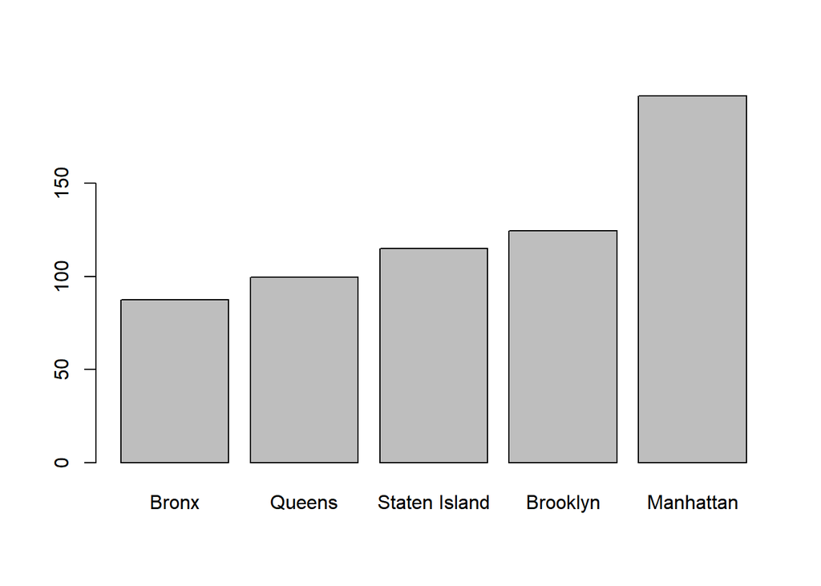

```r
# Plotting the rental rates by borough
barplot(price_per_neighborhood)
```

The most expensive borough for airbnbs is Manhattan and the second most expensive is Brooklyn. On top of that, the most airbnbs are located in Manhattan and the second most are located in Brooklyn. A good future study with this data would be to see population size of the two boroughs and to see which tourist attractions are closest to each borough to see if the increased prices are justifiable.

### Info about Manhattan

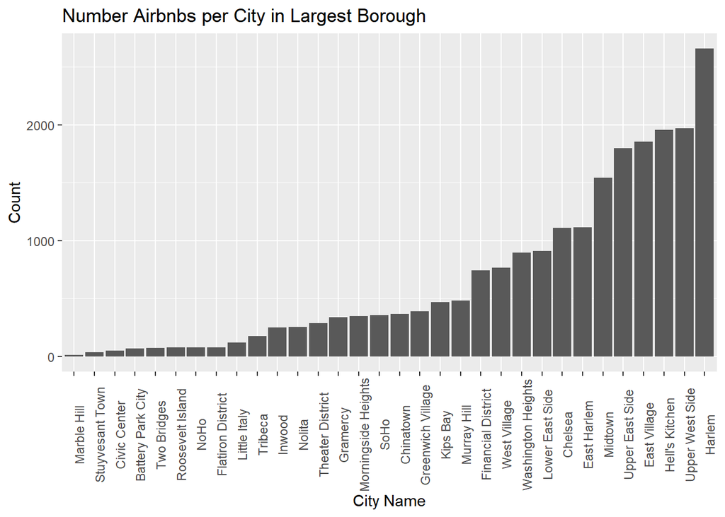

```r
# Number of airbnbs in the cities in the largest borough in NYC
city_group <- data.frame(sort(table(select(filter(airbnb, neighbourhood_group == "Manhattan"), neighbourhood))))

city_group %>%
  ggplot(aes(x=Var1, y=Freq)) +
  geom_bar(stat='identity') +
  labs(title="Number Airbnbs per City in Largest Borough", x="City Name", y="Count") +
  theme(axis.text.x = element_text(angle = 90))
```

As we can see, the top two cities where the highest number of airbnbs are located are in Manhattan are Harlem and Upper West Side respectively.

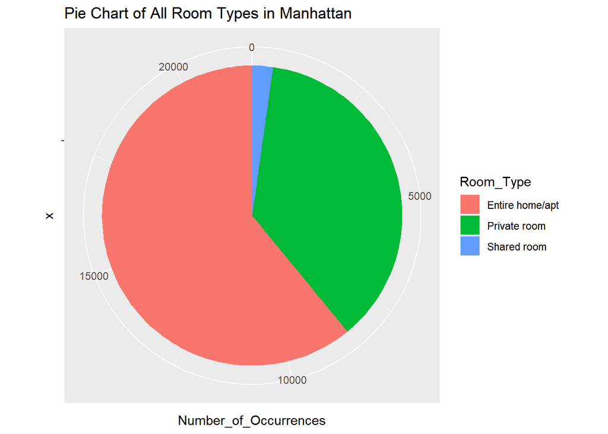

```r
# Pie Chart of types of airbnbs in Manhattan
man_wiz <- data.frame(table(select(filter(airbnb, neighbourhood_group == "Manhattan"), room_type)))
names(man_wiz)[names(man_wiz) == "Var1"] <- "Room_Type"
names(man_wiz)[names(man_wiz) == "Freq"] <- "Number_of_Occurrences"

man_wiz %>%
  ggplot(aes(x="", y=Number_of_Occurrences, fill=Room_Type)) +
  geom_bar(stat="identity", width=1) +
  labs(title="Pie Chart of All Room Types in Manhattan") +
  coord_polar("y", start=0)
```

```r
# Average price by room type
wiz_price <- select(filter(airbnb, neighbourhood_group == "Manhattan"), room_type, price)

price_per_airbnb_type_man <- round(tapply(wiz_price$price,
                  wiz_price$room_type, mean, na.rm=TRUE), 2)
price_per_airbnb_type_man
```

```
## Entire home/apt    Private room     Shared room
##          249.24          116.78           88.98
```

When comparing the types of airbnbs in Manhattan to all of NYC, Manhattan has more Entire home/apts than all of NYC. On top of that Manhattan has higher average prices for all airbnb types than all of NYC.

## Exploratory Data Analysis

### Minimum Nights by Price

[figure not shown]

```r
# Scatterplot of price by minimum night
airbnb %>%
  filter(price < 1000) %>%
  ggplot(aes(x = minimum_nights, y = price)) +
  geom_point() +
  labs(title="Price of Airbnb by Minimum Nights", x="Minimum Nights", y="Price")
```

This graph is being used to see how the number of minimum nights affects the price per night of the airbnb. From this graph, we can see that with an airbnb that costs more per night, fewer nights are required to be rented, which would be in line with strategic business practices.

### Price by Gender

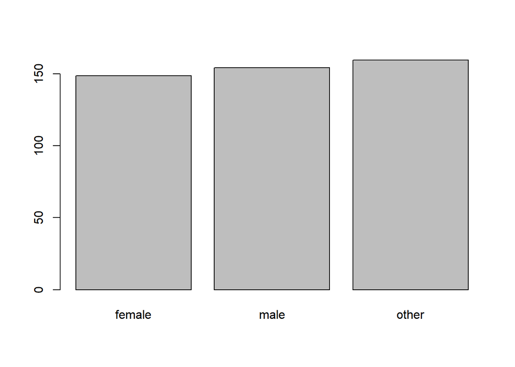

```r
# I used this loop to get the genders of all the names. It took a super long time so I created a new CSV with it. I left it here commented out to show you.# airbnb$gender <- "other"

# airbnb$gender <- "other"
# num <- 1
#
# for(i in airbnb$host_name) {
#   if (nrow(gender(i)['gender']) == 0) {
#     airbnb$gender[num] <- "other"
#   }
#   else if (gender(i)['gender'] == "male"){
#     airbnb$gender[num] <- "male"
#   }
#   else {
#     airbnb$gender[num] <- "female"
#   }
#   print(num)
#   num <- num + 1
# }
#
# write.csv(airbnb, file = "Modified_AB_NYC_2019.csv")

# Calculating the average rental price by borough
price_per_gender <- sort(round(tapply(airbnb$price, airbnb$gender, mean, na.rm=TRUE), 2))

# Calculatiing the average rental rate by gender
barplot(price_per_gender)
```

For price by gender, it seems that other charges more on average. Other is a combination of male, female, and combinations of owners, so it’s difficult to make an analysis for this group. For the other group, it seems that males charge more than females on average for their airbnb rentals.

### Review Importance

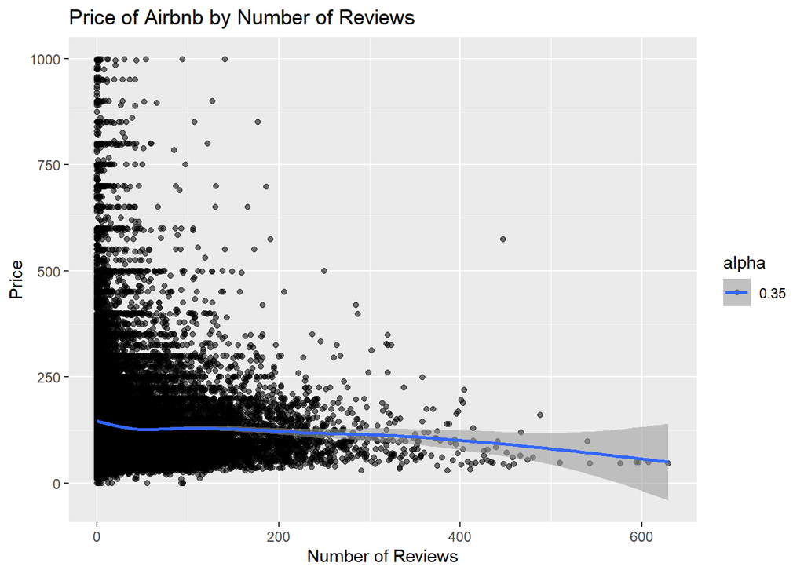

```r
# Scatterplot of reviews per airbnb less than $1000
airbnb %>%
  filter(price < 1000) %>%
  ggplot(aes(x = number_of_reviews, y = price, alpha = .35)) +
  geom_point() +
  geom_smooth() +
  labs(title="Price of Airbnb by Number of Reviews", x="Number of Reviews", y="Price")
```

Interestingly, the more expensive an airbnb is, the fewer reviews it tends to have. This is probably because fewer people rent the airbnb due to its price. Fewer peoplw renting it means fewer people reviewing.

### Description Effect on Price

#### Length of Description on Price

[figure not shown]

```r
# Counting the number of words in each description
airbnb$name_length <- 0
num <- 1

for(i in airbnb$name){
  airbnb$name_length[num] <- sapply(strsplit(i, " "), length)
  num <- num + 1
}

name_length_price <- slice(airbnb, name_length, price)

# Scatterplot that shows description length vs. price
name_length_price %>%
  filter(price < 1000) %>%
  ggplot(aes(x = name_length, y = price, alpha = .35)) +
  geom_point()  +
  labs(title="Price of Airbnb by Description Length", x="Description Length (Number of Words)", y="Price")
```

It seems that the price of an airbnb is somewhat correlated with the length of the description. The distribution seems to be normal, meaning that having a description with four words or less or eight words or more does not correlate to higher priced airbnbs. The sweet spot that gets the most money are descriptions that are from five to seven words long. Being too descriptive or not descriptive enough hurts the owner.

#### Frequency of Key Words on Price

```r
# I used this block to create a CSV with the most frequent words. I stored it in a CSV because it took pretty long to run. I also had to exclude a few words because the annotation did not accurately classify their part of speech.

# udmodel <- udpipe_load_model(model$file_model)
#
# desc <- udpipe_annotate(udmodel, airbnb$name)
# desc <- data.frame(desc)
#
# keyw <- textrank_keywords(desc$lemma,
#                           relevant = desc$upos %in% c("NOUN", "VERB", "ADJ"))
# sub_key <- filter(subset(keyw$keywords, ngram == 1 & freq > 1),
#                   keyword != 'in',
#                   keyword != 'with',
#                   keyword != 'near')
# sub_key
# write.csv(sub_key, file = "Word_Freq.csv")
```

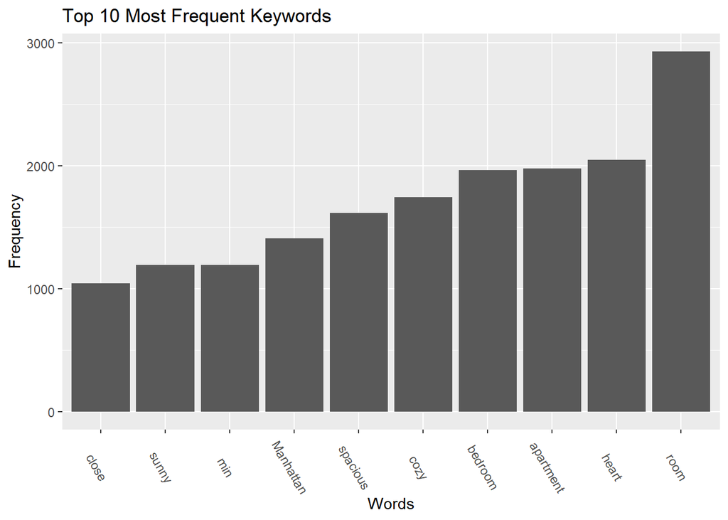

```r
# Load in frequency CSV and get top 10 words for all descriptions
word_freq <- read.csv('Word_Freq.csv')
word_freq$X <- NULL
word_freq <- slice(word_freq, 1:10)

# Bar graph of top 10 most frequent words
word_freq %>%
  ggplot(aes(x = reorder(keyword, freq), y = freq)) +
  geom_bar(stat='identity') +
  theme(axis.text.x = element_text(angle = -60))  +
  labs(title="Top 10 Most Frequent Keywords", x="Words", y="Frequency")
```

This is the top 10 most frequent words in every description. It makes sense that room is the top word as most people would be describing their airbnb with the word “room”. The second most used word is heart, and I would assume that’s to entice people to rent their airbnb because its in the “Heart of the City”.

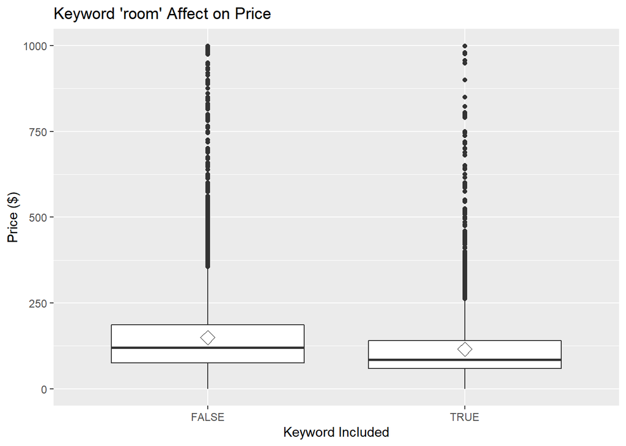

```r
# Creating vectors to assign to new dataframe columns
for (i in 1:10){
  assign(paste("vec", i, sep = ""), grepl(word_freq$keyword[i], airbnb$name))
}

# Assigning vectors to different columns -- this could be more efficient, but I can't figure it out
airbnb$room <- vec1
airbnb$heart <- vec2
airbnb$apartment <- vec3
airbnb$bedroom <- vec4
airbnb$cozy <- vec5
airbnb$spacious <- vec6
airbnb$Manhattan <- vec7
airbnb$min <- vec8
airbnb$sunny <- vec9
airbnb$close <- vec10

# Room vs. Price Boxplot
airbnb %>%
  filter(price < 1000) %>%
  ggplot(aes(x=room, y=price)) +
  geom_boxplot() +
  labs(title="Keyword 'room' Affect on Price", x="Keyword Included", y="Price ($)") +
  stat_summary(fun=mean, geom="point", shape=23, size=4)
```

It doesn’t look like having the word “room” in the description correlates to a higher price for the airbnb. It makes sense as most of the owners would probably have the word “room” when describing their listing.

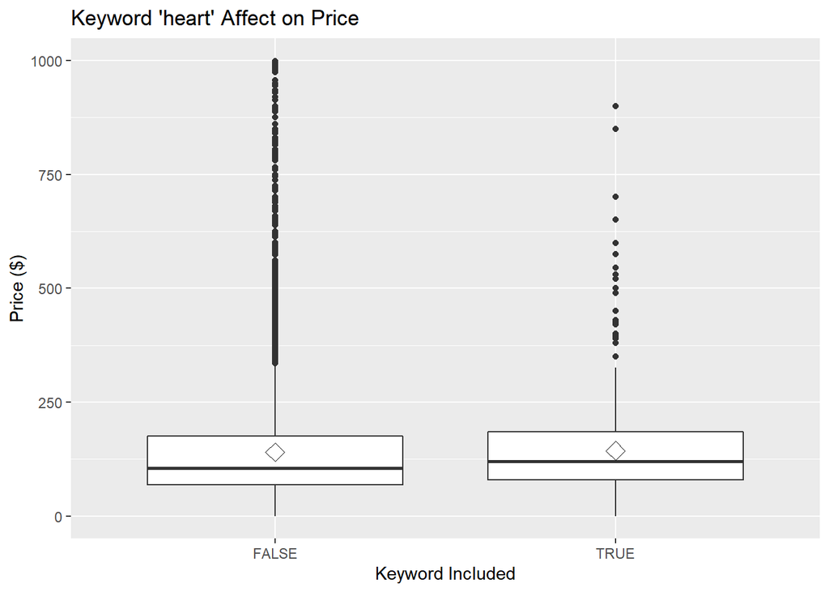

```r
# Heart vs. Price Boxplot
airbnb %>%
  filter(price < 1000) %>%
  ggplot(aes(x=heart, y=price)) +
  geom_boxplot() +
  labs(title="Keyword 'heart' Affect on Price", x="Keyword Included", y="Price ($)") +
  stat_summary(fun=mean, geom="point", shape=23, size=4)
```

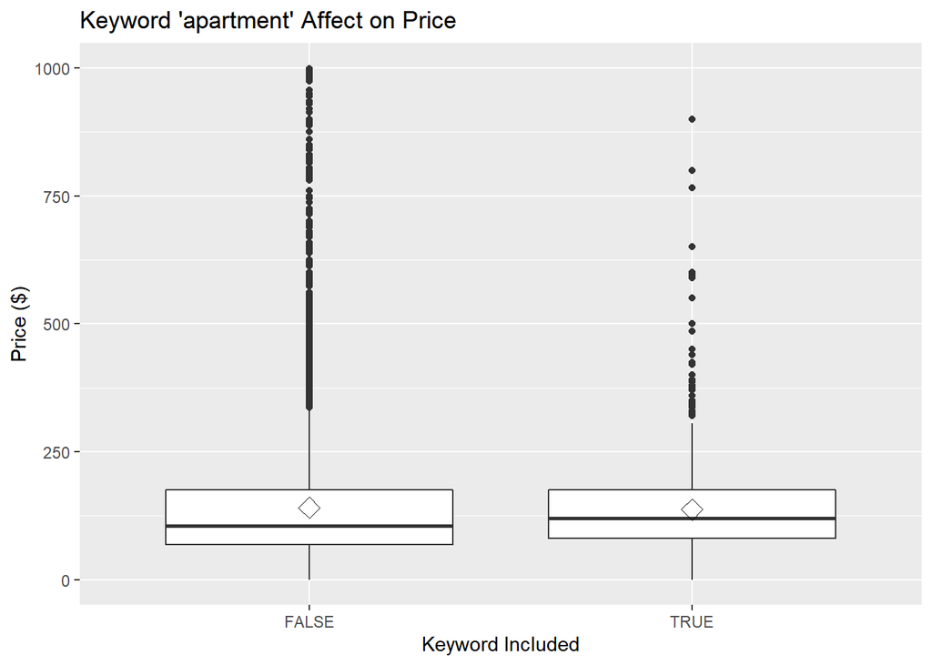

```r
# Apartment vs. Price Boxplot
airbnb %>%
  filter(price < 1000) %>%
  ggplot(aes(x=apartment, y=price)) +
  geom_boxplot() +
  labs(title="Keyword 'apartment' Affect on Price", x="Keyword Included", y="Price ($)") +
  stat_summary(fun=mean, geom="point", shape=23, size=4)
```

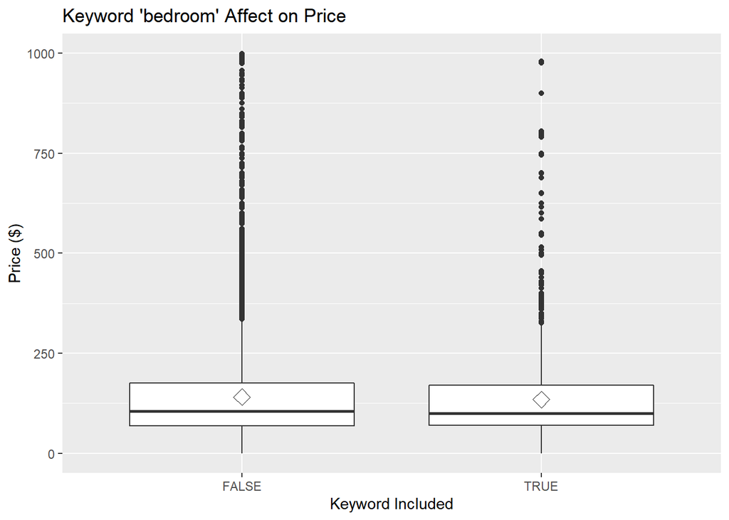

```r
# Bedroom vs. Price Boxplot
airbnb %>%
  filter(price < 1000) %>%
  ggplot(aes(x=bedroom, y=price)) +
  geom_boxplot() +
  labs(title="Keyword 'bedroom' Affect on Price", x="Keyword Included", y="Price ($)") +
  stat_summary(fun=mean, geom="point", shape=23, size=4)
```

The word “bedroom” doesn’t seem to correlate to higher pricing of airbnbs.

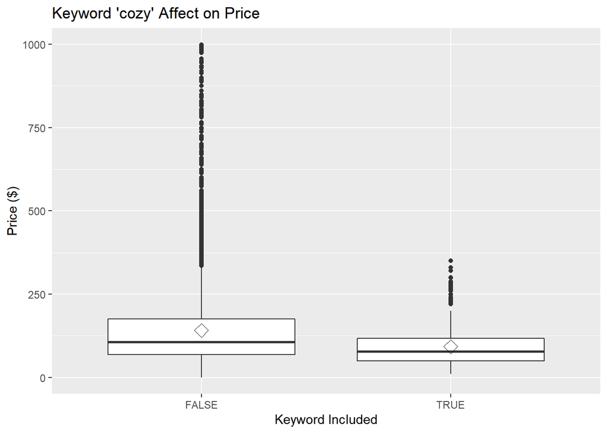

```r
# Cozy vs. Price Boxplot
airbnb %>%
  filter(price < 1000) %>%
  ggplot(aes(x=cozy, y=price)) +
  geom_boxplot() +
  labs(title="Keyword 'cozy' Affect on Price", x="Keyword Included", y="Price ($)") +
  stat_summary(fun=mean, geom="point", shape=23, size=4)
```

Surprisingly, the word “cozy” doesn’t correlate to higher pricing. In fact, the pricing of airbnbs with “cozy” in the description correlate with lower pricing. That’s probably because “cozy” is just a fancy way to say “small”, and they can’t charge as much for smaller places.

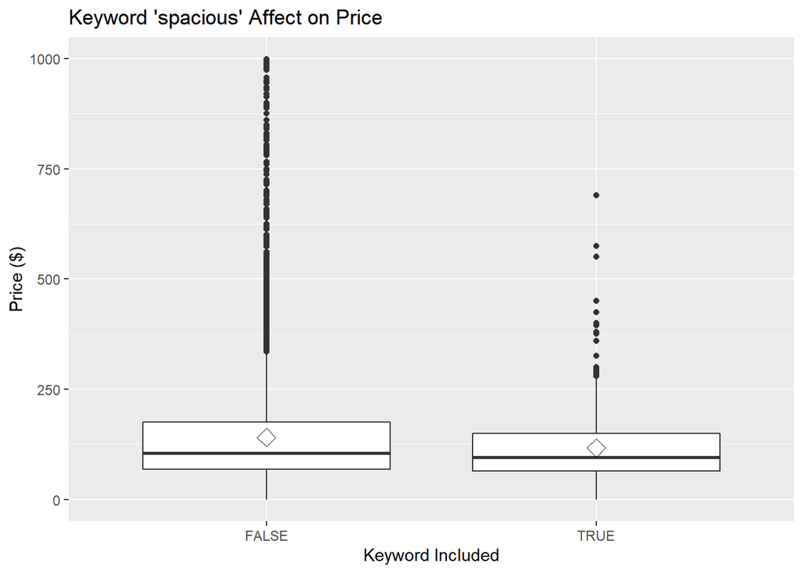

```r
# Spacious vs. Price Boxplot
airbnb %>%
  filter(price < 1000) %>%
  ggplot(aes(x=spacious, y=price)) +
  geom_boxplot() +
  labs(title="Keyword 'spacious' Affect on Price", x="Keyword Included", y="Price ($)") +
  stat_summary(fun=mean, geom="point", shape=23, size=4)
```

Surprisingly, the word “spacious” doesn’t correlate to higher pricing. In fact, the pricing of airbnbs with “spacious” in the description correlate with lower pricing. That’s probably because nothing is “spacious” in New York City.

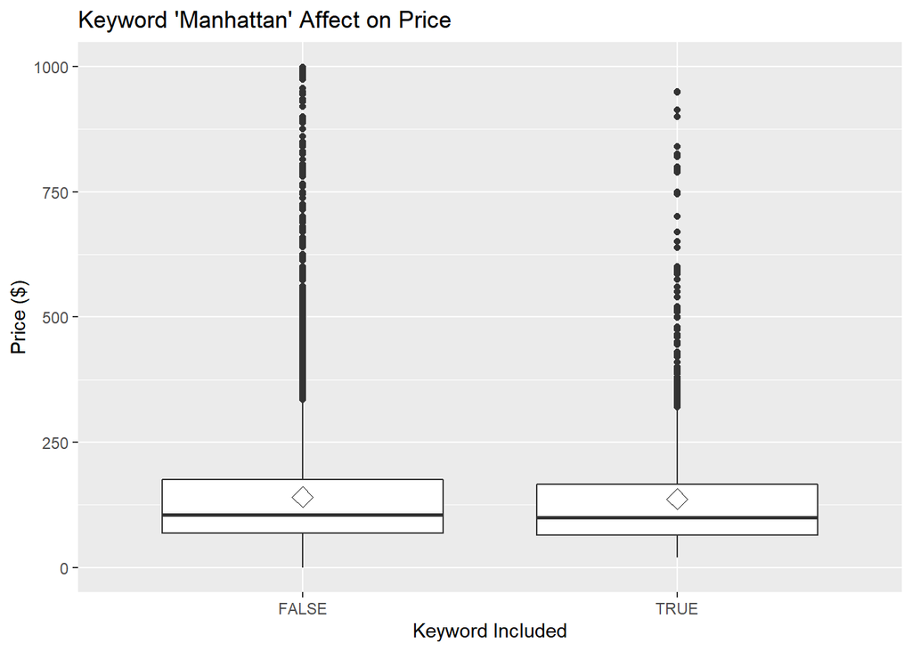

```r
# Manhattan vs. Price Boxplot
airbnb %>%
  filter(price < 1000) %>%
  ggplot(aes(x=Manhattan, y=price)) +
  geom_boxplot() +
  labs(title="Keyword 'Manhattan' Affect on Price", x="Keyword Included", y="Price ($)") +
  stat_summary(fun=mean, geom="point", shape=23, size=4)
```

The word “Manhattan” does not correlate with higher priced airbnbs.

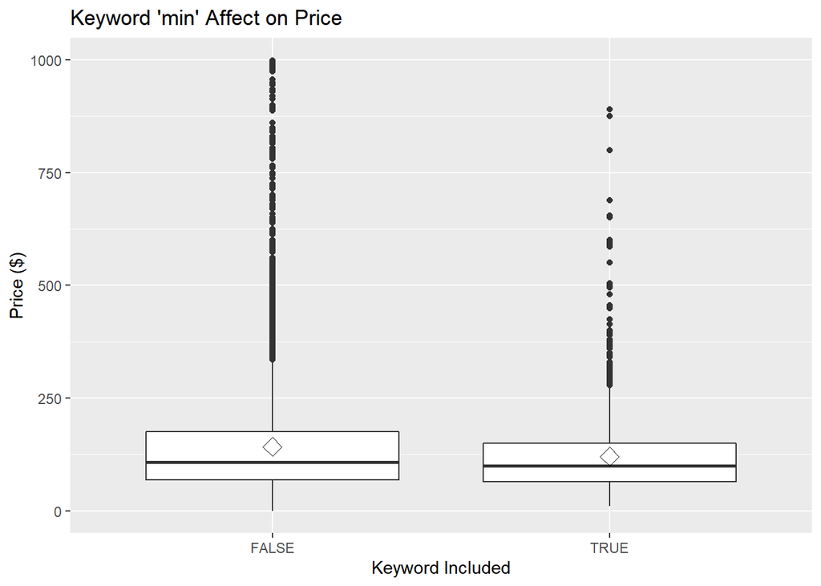

```r
# Min vs. Price Boxplot
airbnb %>%
  filter(price < 1000) %>%
  ggplot(aes(x=min, y=price)) +
  geom_boxplot() +
  labs(title="Keyword 'min' Affect on Price", x="Keyword Included", y="Price ($)") +
  stat_summary(fun=mean, geom="point", shape=23, size=4)
```

The word “min” does not correlate with higher priced airbnbs. The word “min” probably refers to “minute”, which is used to described how many minutes away the airbnb would be from a certain locaation i.e “5 min from city”.

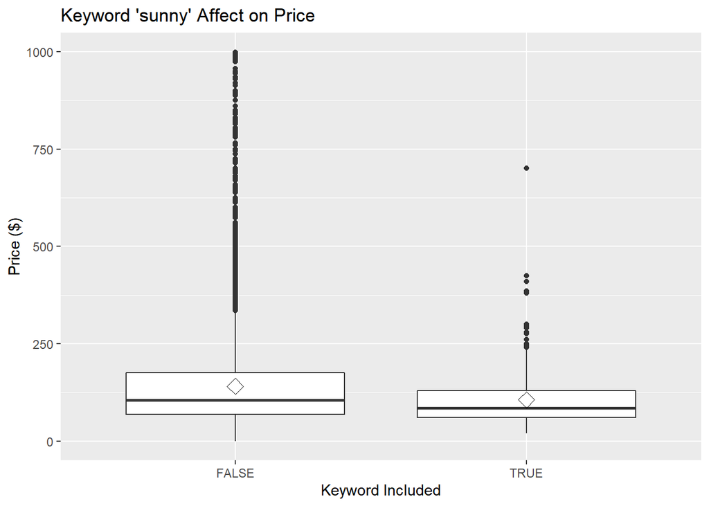

```r
# Sunny vs. Price Boxplot
airbnb %>%
  filter(price < 1000) %>%
  ggplot(aes(x=sunny, y=price)) +
  geom_boxplot() +
  labs(title="Keyword 'sunny' Affect on Price", x="Keyword Included", y="Price ($)") +
  stat_summary(fun=mean, geom="point", shape=23, size=4)
```

The word “sunny” doesn’t correlate to higher pricing. In fact, the pricing of airbnbs with “sunny” in the description correlate with lower pricing.

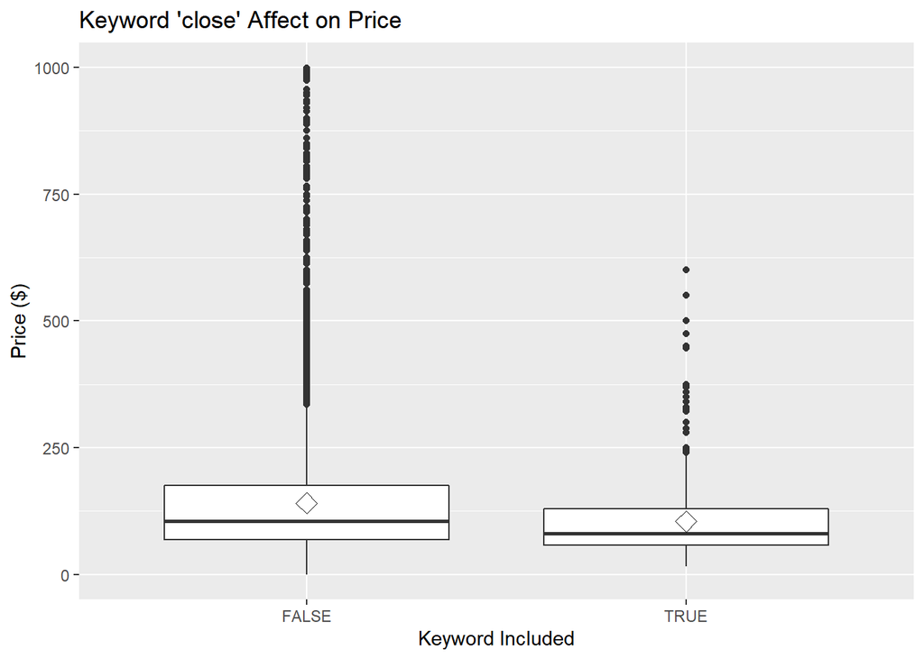

```r
# Close vs. Price Boxplot
airbnb %>%
  filter(price < 1000) %>%
  ggplot(aes(x=close, y=price)) +
  geom_boxplot() +
  labs(title="Keyword 'close' Affect on Price", x="Keyword Included", y="Price ($)") +
  stat_summary(fun=mean, geom="point", shape=23, size=4)
```

The word “close” doesn’t correlate to higher pricing. In fact, the pricing of airbnbs with “close” in the description correlate with lower pricing.

```r
# Wrote more CSVs to once again speed up the process

# # Creating the top and bottom 1000 priced airbnbs
# ordered_bnb <- airbnb[order(-airbnb$price),]
# top_1000 <- slice(select(ordered_bnb, name), 1:1000)
# bottom_1000 <- slice(select(ordered_bnb, name), 48895:47895)
#
# # Finding the most frequent words for the top 1000 priced airbnbs
# desc_top <- udpipe_annotate(udmodel, top_1000$name)
# desc_top <- data.frame(desc_top)
#
# keyw_top <- textrank_keywords(desc_top$lemma,
#                           relevant = desc_top$upos %in% c("NOUN", "VERB", "ADJ"))
# sub_key_top <- filter(subset(keyw_top$keywords, ngram == 1 & freq > 1),
#                   keyword != 'in',
#                   keyword != 'with',
#                   keyword != 'near')
#
# # Finding the most frequent words for the bottom 1000 priced airbnbs
# desc_bottom <- udpipe_annotate(udmodel, bottom_1000$name)
# desc_bottom <- data.frame(desc_bottom)
#
# keyw_bottom <- textrank_keywords(desc_bottom$lemma,
#                           relevant = desc_bottom$upos %in% c("NOUN", "VERB", "ADJ"))
# sub_key_bottom <- filter(subset(keyw_bottom$keywords, ngram == 1 & freq > 1),
#                   keyword != 'in',
#                   keyword != 'with',
#                   keyword != 'near')
#
# # Writing CSVs for the top and bottom 1000 priced frequent words
# write.csv(sub_key_top, file = "Top_Word_Freq.csv")
# write.csv(sub_key_bottom, file = "Bottom_Word_Freq.csv")
```

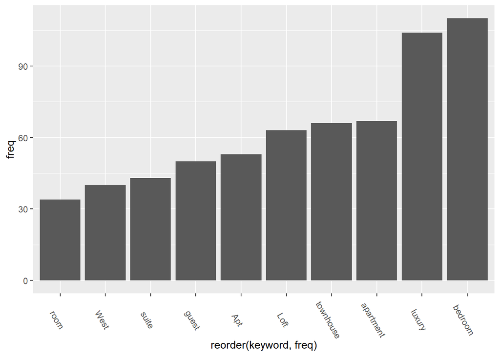

```r
# Load in frequency CSV and get top 10 words for top 1000 descriptions
top_word_freq <- read.csv('Top_Word_Freq.csv')
top_word_freq$X <- NULL
top_word_freq <- slice(top_word_freq, 1:10)

# Bar graph of top 10 frequent words in top 1000 priced airbnbs
top_word_freq %>%
  ggplot(aes(x = reorder(keyword, freq), y = freq)) +
  geom_bar(stat='identity') +
  theme(axis.text.x = element_text(angle = -60))
```

I found the most frequent keywords for the 1000 most expensive airbnbs. The word “room” makes the list but at position ten as opposed to one. We see other words like “luxury”, “townhouse”, and “loft” that are probably in the descriptions to justify the higher pricing of the airbnbs. Because of the expensive apartment pricing in Manahttan and because of the greater share of airbnbs in Manhattan are apartments, “apartment” and “apt” are probably the words that drive the average prices up.

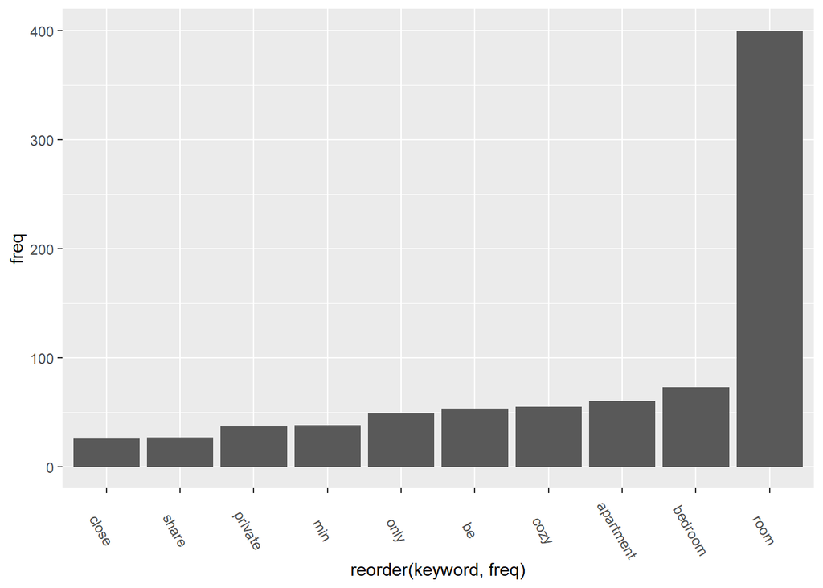

```r
# Load in frequency CSV and get top 10 words for bottom 1000 descriptions
bottom_word_freq <- read.csv('Bottom_Word_Freq.csv')
bottom_word_freq$X <- NULL
bottom_word_freq <- slice(bottom_word_freq, 1:10)

# Bar graph of top 10 frequent words in bottom 1000 priced airbnbs
bottom_word_freq %>%
  ggplot(aes(x = reorder(keyword, freq), y = freq)) +
  geom_bar(stat='identity') +
  theme(axis.text.x = element_text(angle = -60))
```

I found the most frequent keywords for the 1000 least expensive airbnbs. The word “room” is once again at the top of the list. As we can see, the words that did not correlate to higher prices, like “cozy”, “close”, and “min”, also appear on this list.

## Expensive Rentals on a Map

```r
lat_long_price <- airbnb[order(-airbnb$price),]
lat_long_price <- slice(select(lat_long_price, latitude, longitude, price), 1:100)

leaflet() %>%
  addProviderTiles(providers$Esri.WorldGrayCanvas) %>%
  addCircles(data = lat_long_price, weight = 5)
```

```
## Assuming "longitude" and "latitude" are longitude and latitude, respectively
```

[interactive chart not shown]

The majority of the most expensive airbnbs appear in Manhattan. This is in line with the graphs from above that showed that Manhattan has the most airbnbs and that it has the most expensive pricing for airbnbs on average.